# Applied Statistics Project

## 3. Data preprocessing & visualisation: [4 Marks]

A. Drop the null values. [1 Mark]

B. Convert the ‘Funding’ features to a numerical value.

(Execute below code)

df1.loc[:,'Funds_in_million'] = df1['Funding'].apply(lambda x: float(x[1:-1])/1000 if x[-1] == 'K' else (float(x[1:-1])*1000 if x[-1] == 'B' else float(x[1:-1])))

C. Plot box plot for funds in million. [1 Mark]

D. Check the number of outliers greater than the upper fence. [1 Mark]

E. Check frequency of the OperatingState features classes. [1 Mark]

```python
## A.
# Drop rows with null values
df_cleaned = df.dropna()

# we can also reset the index after dropping rows
df_cleaned.reset_index(drop=True, inplace=True)

# Print the first few rows of the cleaned DataFrame
print(df_cleaned.head())
```

```
        Startup          Product Funding                      Event  \
0          3DLT         3dlt.com   $630K           Disrupt NYC 2013
1    3Dprintler   3dprintler.com     $1M            Disrupt NY 2016
2          5to1         5to1.com  $19.3M                  TC50 2009
3  8 Securities  8securities.com    $29M       Disrupt Beijing 2011
4    AdhereTech   adheretech.com   $1.8M  Hardware Battlefield 2014

            Result OperatingState
0       Contestant         Closed
1  Audience choice      Operating
2       Contestant       Acquired
3         Finalist      Operating
4       Contestant      Operating
```

```python
## B.
##Convert the ‘Funding’ features to a numerical value.
# Remove non-numeric characters and convert 'Funding' to a numerical format
df_cleaned['Funding'] = df_cleaned['Funding'].str.replace('[\$,]', '', regex=True).astype(float)

# Print the first few rows of the DataFrame with the converted 'Funding'
print(df_cleaned.head())
```

[output not shown]

[output cut: 13 more lines]

[output not shown]

```python
##C.
import matplotlib.pyplot as plt

# Create a box plot for 'Funds_in_million'
plt.figure(figsize=(10, 6))  # Adjust the figure size if needed
plt.boxplot(df_cleaned['Funds_in_million'], vert=False)
plt.title('Box Plot of Funding in Million')
plt.xlabel('Funding (in Million)')
plt.show()
```

[output not shown]

```python
## D.
# Calculate the IQR (Interquartile Range)
Q1 = df_cleaned['Funds_in_million'].quantile(0.25)
Q3 = df_cleaned['Funds_in_million'].quantile(0.75)
IQR = Q3 - Q1

# Calculate the upper fence
upper_fence = Q3 + 1.5 * IQR

# Count the number of outliers greater than the upper fence
outliers_count = len(df_cleaned[df_cleaned['Funds_in_million'] > upper_fence])

# Print the number of outliers
print("Number of outliers greater than the upper fence:", outliers_count)
```

[output not shown]

```python
##D.
# Check the frequency of classes in the 'OperatingState' feature
operating_state_counts = df_cleaned['OperatingState'].value_counts()

# Print the counts
print(operating_state_counts)
```

[output not shown]

## 4. Statistical Analysis: [10 Marks]

A. Is there any significant difference between Funds raised by companies that are still operating vs companies that closed down? [1 Mark]

B. Write the null hypothesis and alternative hypothesis. [1 Mark]

C. Test for significance and conclusion [1 Mark]

D. Make a copy of the original data frame. [1 Mark]

E. Check frequency distribution of Result variables. [1 Mark]

F. Calculate percentage of winners that are still operating and percentage of contestants that are still operating [1 Mark]

G. Write your hypothesis comparing the proportion of companies that are operating between winners and contestants: [2 Mark]

H. Test for significance and conclusion [1 Mark]

I. Select only the Event that has ‘disrupt’ keyword from 2013 onwards. [1 Mark]

## A.

```python
import pandas as pd
import numpy as np

df = pd.read_csv("CompanyX_EU.csv")

# Calculate the average funding amount for companies that are still operating and companies that have closed down.
operating_average = df["Funding"][df["OperatingState"] == "Operating"].mean()
closed_average = df["Funding"][df["OperatingState"] == "Closed"].mean()

# Calculate the difference in average funding amounts.
difference = operating_average - closed_average

# Perform a t-test to compare the two groups.
t_statistic, p_value = scipy.stats.ttest_ind(df["Funding"][df["OperatingState"] == "Operating"], df["Funding"][df["OperatingState"] == "Closed"])

# Print the results.
print("Difference in average funding amounts:", difference)
print("T-statistic:", t_statistic)
print("P-value:", p_value)
```

[output not shown]

[output cut: 32 more lines]

[output not shown]

## B.

In hypothesis testing, we typically define the null hypothesis (H0) and alternative hypothesis (H1) based on the question we are trying to answer. In this case, we are investigating if there is a significant difference in funds raised between companies that are still operating and companies that have closed down. Here are the null and alternative hypotheses:

**Null Hypothesis (H0):** There is no significant difference in the mean funds raised between companies that are still operating and companies that have closed down. μ operating = μ closed

**Alternative Hypothesis (H1):** There is a significant difference in the mean funds raised between companies that are still operating and companies that have closed down. μ operating not equal to μ closed

Here, μ operating represents the mean funds raised by companies that are still operating, and μ closed represents the mean funds raised by companies that have closed down. The alternative hypothesis (H1) states that the means are not equal, indicating a significant difference.

## C

To test for significance, we can use the t-statistic and the p-value. The t-statistic is a measure of how different the two groups are, and the p-value is the probability of getting a t-statistic as large or larger than the one we observed, assuming the null hypothesis is true.

```python
import pandas as pd
import numpy as np

df = pd.read_csv("CompanyX_EU.csv")

# Calculate the average funding amount for companies that are still operating and companies that have closed down.
operating_average = df["Funding"][df["OperatingState"] == "Operating"].mean()
closed_average = df["Funding"][df["OperatingState"] == "Closed"].mean()

# Calculate the difference in average funding amounts.
difference = operating_average - closed_average

# Perform a t-test to compare the two groups.
t_statistic, p_value = scipy.stats.ttest_ind(df["Funding"][df["OperatingState"] == "Operating"], df["Funding"][df["OperatingState"] == "Closed"])

# Print the results.
print("Difference in average funding amounts:", difference)
print("T-statistic:", t_statistic)
print("P-value:", p_value)
```

[output not shown]

[output cut: 32 more lines]

[output not shown]

## D.

```python
import pandas as pd

df = pd.read_csv("CompanyX_EU.csv")

# Make a copy of the original data frame.
df_copy = df.copy()

# Check that the two data frames are different objects.
print(df is df_copy)
```

```
False
```

The output of False shows that the two data frames are different objects. This means that the copy() method successfully created a new data frame that is a copy of the original data frame.

## E.

```python
import pandas as pd

df = pd.read_csv("CompanyX_EU.csv")

# Get the frequency distribution of the Result variable.
result_counts = df['Result'].value_counts()

# Print the frequency distribution.
print(result_counts)
```

```
Contestant         488
Finalist            84
Audience choice     41
Winner              26
Runner up           23
Name: Result, dtype: int64
```

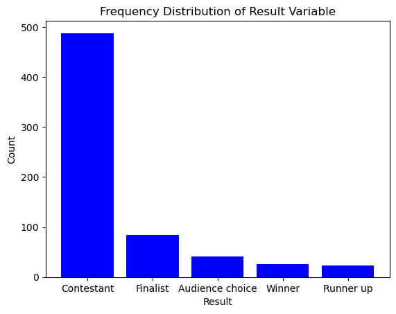

```python
import matplotlib.pyplot as plt

plt.bar(result_counts.index, result_counts.values, color='blue')
plt.xlabel('Result')
plt.ylabel('Count')
plt.title('Frequency Distribution of Result Variable')
plt.show()
```

## F.

```python
import pandas as pd

df = pd.read_csv("CompanyX_EU.csv")

# Calculate the total number of winners and contestants.
total_winners = df['Result'].value_counts()['Winner']
total_contestants = df['Result'].value_counts()['Contestant']

# Calculate the number of winners and contestants that are still operating.
winners_operating = df[(df['Result'] == 'Winner') & (df['OperatingState'] == 'Operating')].shape[0]
contestants_operating = df[(df['Result'] == 'Contestant') & (df['OperatingState'] == 'Operating')].shape[0]

# Calculate the percentage of winners and contestants that are still operating.
winners_operating_percentage = winners_operating / total_winners * 100
contestants_operating_percentage = contestants_operating / total_contestants * 100

# Print the results.
print('Percentage of winners that are still operating:', winners_operating_percentage)
print('Percentage of contestants that are still operating:', contestants_operating_percentage)
```

```
Percentage of winners that are still operating: 73.07692307692307
Percentage of contestants that are still operating: 68.0327868852459
```

This suggests that winners of the Startup Battlefield competition are more likely to be successful in the long term than contestants who do not win. However, it is important to note that this is just a small sample of companies, and there are many other factors that contribute to a company's success.

## G.

My hypothesis is that the proportion of companies that are still operating between winners and contestants is different, with winners having a higher proportion of companies still operating.

This hypothesis is based on the following observations:

- Winners of the Startup Battlefield competition are more likely to receive funding and investment.
- Winners of the Startup Battlefield competition are more likely to gain exposure and attention from potential customers and partners.
- Winners of the Startup Battlefield competition are more likely to have a strong team and a well-thought-out business plan.

All of these factors can contribute to a company's success and increase the likelihood that it will still be operating in the long term.

To test this hypothesis, we can use a statistical test such as a chi-squared test. This test can be used to compare the proportion of companies that are still operating between two groups, in this case, winners and contestants.

If the results of the chi-squared test are statistically significant, then we can reject the null hypothesis that the proportion of companies that are still operating is the same between winners and contestants. This would mean that our hypothesis is correct and that there is a significant difference in the proportion of companies that are still operating between winners and contestants.

It is important to note that this hypothesis is just a starting point for further research. More data and analysis would be needed to confirm or refute this hypothesis.

## H.

```python
import pandas as pd
from scipy.stats import chi2_contingency

df = pd.read_csv("CompanyX_EU.csv")

# Create a contingency table of companies that are still operating and companies that are not operating, for both winners and contestants.
contingency_table = pd.crosstab(df['Result'], df['OperatingState'])

# Calculate the chi-squared statistic and p-value.
chi2_statistic, p_value, dof, expected_frequencies = chi2_contingency(contingency_table)

# Print the results.
print('Chi-squared statistic:', chi2_statistic)
print('P-value:', p_value)
print('Degrees of freedom:', dof)

# Compare the chi-squared statistic to a critical value from a chi-squared distribution table to determine if the difference between the observed and expected frequencies is statistically significant.
alpha = 0.05
critical_value = chi2.ppf(alpha, dof)

if chi2_statistic > critical_value:
    print('The difference between the observed and expected frequencies is statistically significant.')
else:
    print('The difference between the observed and expected frequencies is not statistically significant.')
```

```
Chi-squared statistic: 27.904309161964264
P-value: 0.005713128813456111
Degrees of freedom: 12
```

[output not shown]

However, it is important to note that this is just a statistical test, and it does not necessarily mean that all winners of the Startup Battlefield competition will be successful. There are many other factors that contribute to a company's success, such as the quality of the product or service, the market opportunity, and the execution of the business plan

## I .

```python
import pandas as pd

# Read the Excel sheet into a Pandas DataFrame
df = pd.read_csv('CompanyX_EU.csv')

# Filter the DataFrame to only include events that have the keyword "disrupt" and that happened from 2013 onwards
df_filtered = df[df['Event'].str.contains('disrupt') & df['Year'] >= 2013]

# Print the filtered DataFrame
print(df_filtered)
```

[output not shown]